# Image features exercise

*Complete and hand in this completed worksheet (including its outputs and any supporting code outside of the worksheet) with your assignment submission. For more details see the [assignments page](http://vision.stanford.edu/teaching/cs231n/assignments.html) on the course website.*

We have seen that we can achieve reasonable performance on an image classification task by training a linear classifier on the pixels of the input image. In this exercise we will show that we can improve our classification performance by training linear classifiers not on raw pixels but on features that are computed from the raw pixels.

All of your work for this exercise will be done in this notebook.

```python
import random
import numpy as np
from cs231n.data_utils import load_CIFAR10
import matplotlib.pyplot as plt
%matplotlib inline
plt.rcParams['figure.figsize'] = (10.0, 8.0) # set default size of plots
plt.rcParams['image.interpolation'] = 'nearest'
plt.rcParams['image.cmap'] = 'gray'

# for auto-reloading extenrnal modules
# see http://stackoverflow.com/questions/1907993/autoreload-of-modules-in-ipython
%load_ext autoreload
%autoreload 2
```

## Load data

Similar to previous exercises, we will load CIFAR-10 data from disk.

```python
from cs231n.features import color_histogram_hsv, hog_feature

def get_CIFAR10_data(num_training=49000, num_validation=1000, num_test=1000):
  # Load the raw CIFAR-10 data
  cifar10_dir = 'cs231n/datasets/cifar-10-batches-py'
  X_train, y_train, X_test, y_test = load_CIFAR10(cifar10_dir)

  # Subsample the data
  mask = range(num_training, num_training + num_validation)
  X_val = X_train[mask]
  y_val = y_train[mask]
  mask = range(num_training)
  X_train = X_train[mask]
  y_train = y_train[mask]
  mask = range(num_test)
  X_test = X_test[mask]
  y_test = y_test[mask]

  return X_train, y_train, X_val, y_val, X_test, y_test

X_train, y_train, X_val, y_val, X_test, y_test = get_CIFAR10_data()
```

## Extract Features

For each image we will compute a Histogram of Oriented Gradients (HOG) as well as a color histogram using the hue channel in HSV color space. We form our final feature vector for each image by concatenating the HOG and color histogram feature vectors.

Roughly speaking, HOG should capture the texture of the image while ignoring color information, and the color histogram represents the color of the input image while ignoring texture. As a result, we expect that using both together ought to work better than using either alone. Verifying this assumption would be a good thing to try for the bonus section.

```python
from cs231n.features import *

num_color_bins = 10 # Number of bins in the color histogram
feature_fns = [hog_feature, lambda img: color_histogram_hsv(img, nbin=num_color_bins)]
X_train_feats = extract_features(X_train, feature_fns, verbose=True)
X_val_feats = extract_features(X_val, feature_fns)
X_test_feats = extract_features(X_test, feature_fns)

# Preprocessing: Subtract the mean feature
mean_feat = np.mean(X_train_feats, axis=0, keepdims=True)
X_train_feats -= mean_feat
X_val_feats -= mean_feat
X_test_feats -= mean_feat

# Preprocessing: Divide by standard deviation. This ensures that each feature
# has roughly the same scale.
std_feat = np.std(X_train_feats, axis=0, keepdims=True)
X_train_feats /= std_feat
X_val_feats /= std_feat
X_test_feats /= std_feat

# Preprocessing: Add a bias dimension
X_train_feats = np.hstack([X_train_feats, np.ones((X_train_feats.shape[0], 1))])
X_val_feats = np.hstack([X_val_feats, np.ones((X_val_feats.shape[0], 1))])
X_test_feats = np.hstack([X_test_feats, np.ones((X_test_feats.shape[0], 1))])
```

[output not shown]

## Train SVM on features

Using the multiclass SVM code developed earlier in the assignment, train SVMs on top of the features extracted above; this should achieve better results than training SVMs directly on top of raw pixels.

```python
# Use the validation set to tune the learning rate and regularization strength

from cs231n.classifiers.linear_classifier import LinearSVM

learning_rates = [1e-9, 1e-8, 1e-7]
regularization_strengths = [1e5, 1e6, 1e7]

results = {}
best_val = -1
best_svm = None

pass
################################################################################
# TODO:                                                                        #
# Use the validation set to set the learning rate and regularization strength. #
# This should be identical to the validation that you did for the SVM; save    #
# the best trained classifer in best_svm. You might also want to play          #
# with different numbers of bins in the color histogram. If you are careful    #
# you should be able to get accuracy of near 0.44 on the validation set.       #
################################################################################
#for lr in learning_rates:
#    for reg in regularization_strengths:
import random
for i in range(1):
    for j in range(50):
        lr = 10**random.uniform(-6, -3)
        reg= 10**random.uniform(-1,3)
        #reg = 0
        svm = LinearSVM()
        model = svm.train(X_train_feats, y_train, learning_rate = lr, reg = reg,
                         num_iters = 1500, batch_size = 1500)
        train_labels = svm.predict(X_train_feats)
        val_labels = svm.predict(X_val_feats)
        train_accuracy = np.mean(train_labels == y_train)
        val_accuracy = np.mean(val_labels == y_val)
        results[(lr, reg)] = [train_accuracy, val_accuracy]
        if val_accuracy> best_val:
            best_val = val_accuracy
            best_svm = svm
        print 'lr %e reg %e train %f val %f' % (lr, reg, train_accuracy, val_accuracy)
################################################################################
#                              END OF YOUR CODE                                #
################################################################################

# Print out results.
for lr, reg in sorted(results):
    train_accuracy, val_accuracy = results[(lr, reg)]
    print 'lr %e reg %e train accuracy: %f val accuracy: %f' % (
                lr, reg, train_accuracy, val_accuracy)

print 'best validation accuracy achieved during cross-validation: %f' % best_val
```

```
lr 2.643944e-06 reg 2.312898e+01 train 0.356265 val 0.358000
lr 1.137499e-06 reg 6.855789e-01 train 0.264837 val 0.270000
lr 5.958738e-06 reg 1.009350e+00 train 0.400286 val 0.409000
lr 2.301490e-06 reg 1.057276e+01 train 0.350816 val 0.363000
lr 1.795591e-05 reg 2.578272e+02 train 0.415388 val 0.421000
lr 6.668739e-06 reg 9.210092e+02 train 0.415020 val 0.423000
lr 9.183221e-04 reg 2.069777e+00 train 0.482755 val 0.475000
lr 5.645367e-06 reg 6.723781e-01 train 0.395714 val 0.393000
lr 4.067112e-06 reg 7.606357e+00 train 0.381041 val 0.371000
lr 1.761892e-05 reg 4.400115e+01 train 0.415163 val 0.414000
lr 3.105665e-06 reg 3.049837e+00 train 0.378184 val 0.361000
lr 3.469835e-04 reg 4.991667e+00 train 0.466878 val 0.452000
lr 7.353500e-06 reg 3.735291e-01 train 0.409469 val 0.396000
lr 3.597252e-06 reg 1.448829e+01 train 0.388122 val 0.382000
lr 1.771019e-06 reg 1.080618e+02 train 0.325122 val 0.342000
lr 7.888837e-05 reg 6.206713e+01 train 0.415939 val 0.422000
lr 2.231251e-06 reg 3.713639e+00 train 0.334163 val 0.340000
lr 1.280176e-06 reg 5.578177e-01 train 0.288959 val 0.281000
lr 5.556040e-05 reg 5.600711e-01 train 0.433327 val 0.435000
lr 8.866643e-06 reg 4.008913e+02 train 0.415612 val 0.419000
lr 1.711750e-06 reg 3.104824e+02 train 0.352735 val 0.356000
lr 1.258177e-04 reg 1.435637e+01 train 0.438571 val 0.435000
lr 1.213958e-06 reg 1.430809e+01 train 0.248041 val 0.238000
lr 1.030673e-05 reg 1.021364e+02 train 0.415204 val 0.415000
lr 3.366020e-06 reg 7.488793e-01 train 0.367245 val 0.374000
lr 1.152612e-06 reg 2.558547e+02 train 0.301939 val 0.317000
lr 1.232165e-05 reg 4.147597e+02 train 0.416184 val 0.420000
lr 5.616532e-06 reg 5.471405e-01 train 0.402163 val 0.394000
lr 1.321671e-05 reg 5.146638e+01 train 0.414673 val 0.413000
lr 9.721448e-05 reg 9.474291e-01 train 0.450224 val 0.441000
lr 1.062256e-05 reg 4.706980e+02 train 0.415571 val 0.415000
lr 1.055939e-05 reg 1.640519e-01 train 0.406673 val 0.413000
lr 1.142799e-05 reg 4.581554e+00 train 0.415551 val 0.429000
lr 2.108471e-04 reg 3.355475e+00 train 0.465714 val 0.456000
lr 3.089236e-06 reg 1.090897e+01 train 0.378347 val 0.381000
lr 3.480049e-05 reg 3.886803e+00 train 0.422327 val 0.424000
lr 9.517655e-04 reg 2.188167e+02 train 0.416918 val 0.420000
lr 6.669823e-04 reg 4.823975e+01 train 0.415408 val 0.420000
lr 2.926923e-04 reg 1.009670e+02 train 0.414000 val 0.412000
lr 4.847015e-04 reg 5.715639e+00 train 0.464878 val 0.452000
```

[output cut: 46 more lines]

```
lr 1.258177e-04 reg 1.435637e+01 train accuracy: 0.438571 val accuracy: 0.435000
lr 2.108471e-04 reg 3.355475e+00 train accuracy: 0.465714 val accuracy: 0.456000
lr 2.685219e-04 reg 9.479496e+00 train accuracy: 0.453102 val accuracy: 0.447000
lr 2.745951e-04 reg 1.243556e+00 train accuracy: 0.475061 val accuracy: 0.465000
lr 2.926923e-04 reg 1.009670e+02 train accuracy: 0.414000 val accuracy: 0.412000
lr 3.469835e-04 reg 4.991667e+00 train accuracy: 0.466878 val accuracy: 0.452000
lr 3.538971e-04 reg 7.570770e-01 train accuracy: 0.481184 val accuracy: 0.473000
lr 3.853518e-04 reg 7.051981e-01 train accuracy: 0.483714 val accuracy: 0.474000
lr 4.847015e-04 reg 5.715639e+00 train accuracy: 0.464878 val accuracy: 0.452000
lr 6.022520e-04 reg 3.368868e-01 train accuracy: 0.492327 val accuracy: 0.478000
lr 6.669823e-04 reg 4.823975e+01 train accuracy: 0.415408 val accuracy: 0.420000
lr 7.745900e-04 reg 4.175372e+01 train accuracy: 0.417837 val accuracy: 0.422000
lr 9.183221e-04 reg 2.069777e+00 train accuracy: 0.482755 val accuracy: 0.475000
lr 9.517655e-04 reg 2.188167e+02 train accuracy: 0.416918 val accuracy: 0.420000
best validation accuracy achieved during cross-validation: 0.478000
```

```python
# Evaluate your trained SVM on the test set
y_test_pred = best_svm.predict(X_test_feats)
test_accuracy = np.mean(y_test == y_test_pred)
print test_accuracy
```

```
0.484
```

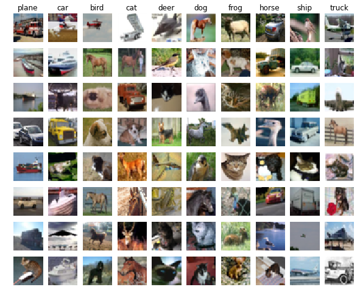

```python
# An important way to gain intuition about how an algorithm works is to
# visualize the mistakes that it makes. In this visualization, we show examples
# of images that are misclassified by our current system. The first column
# shows images that our system labeled as "plane" but whose true label is
# something other than "plane".

examples_per_class = 8
classes = ['plane', 'car', 'bird', 'cat', 'deer', 'dog', 'frog', 'horse', 'ship', 'truck']
for cls, cls_name in enumerate(classes):
    idxs = np.where((y_test != cls) & (y_test_pred == cls))[0]
    idxs = np.random.choice(idxs, examples_per_class, replace=False)
    for i, idx in enumerate(idxs):
        plt.subplot(examples_per_class, len(classes), i * len(classes) + cls + 1)
        plt.imshow(X_test[idx].astype('uint8'))
        plt.axis('off')
        if i == 0:
            plt.title(cls_name)
plt.show()
```

## Neural Network on image features

Earlier in this assigment we saw that training a two-layer neural network on raw pixels achieved better classification performance than linear classifiers on raw pixels. In this notebook we have seen that linear classifiers on image features outperform linear classifiers on raw pixels.

For completeness, we should also try training a neural network on image features. This approach should outperform all previous approaches: you should easily be able to achieve over 55% classification accuracy on the test set; our best model achieves about 60% classification accuracy.

```python
print X_train_feats.shape
```

[output not shown]

```python
from cs231n.classifiers.neural_net import TwoLayerNet

input_dim = X_train_feats.shape[1]
hidden_dim = 500
num_classes = 10

net = TwoLayerNet(input_dim, hidden_dim, num_classes)
stats = net.train(X_train_feats, y_train, X_val_feats, y_val, num_iters = 6000, learning_rate = 0.5, reg = 0.001, verbose=True)
best_net = net

################################################################################
# TODO: Train a two-layer neural network on image features. You may want to    #
# cross-validate various parameters as in previous sections. Store your best   #
# model in the best_net variable.                                              #
################################################################################
pass
################################################################################
#                              END OF YOUR CODE                                #
################################################################################
```

```
iteration 0 / 6000: loss 2.302586
iteration 100 / 6000: loss 1.481386
iteration 200 / 6000: loss 1.360507
iteration 300 / 6000: loss 1.401509
iteration 400 / 6000: loss 1.287631
iteration 500 / 6000: loss 1.345377
iteration 600 / 6000: loss 1.075422
iteration 700 / 6000: loss 1.143239
iteration 800 / 6000: loss 1.215785
iteration 900 / 6000: loss 1.182095
iteration 1000 / 6000: loss 1.096582
iteration 1100 / 6000: loss 1.114659
iteration 1200 / 6000: loss 1.128856
iteration 1300 / 6000: loss 1.067006
iteration 1400 / 6000: loss 1.065675
iteration 1500 / 6000: loss 1.124687
iteration 1600 / 6000: loss 1.051856
iteration 1700 / 6000: loss 0.982226
iteration 1800 / 6000: loss 1.079362
iteration 1900 / 6000: loss 0.905285
iteration 2000 / 6000: loss 0.934059
iteration 2100 / 6000: loss 0.878719
iteration 2200 / 6000: loss 0.855412
iteration 2300 / 6000: loss 0.980249
iteration 2400 / 6000: loss 1.010926
iteration 2500 / 6000: loss 1.053356
iteration 2600 / 6000: loss 1.066289
iteration 2700 / 6000: loss 0.914111
iteration 2800 / 6000: loss 0.966815
iteration 2900 / 6000: loss 0.893261
iteration 3000 / 6000: loss 0.874769
iteration 3100 / 6000: loss 0.868671
iteration 3200 / 6000: loss 0.856406
iteration 3300 / 6000: loss 0.892612
iteration 3400 / 6000: loss 0.810868
iteration 3500 / 6000: loss 0.896102
iteration 3600 / 6000: loss 0.855120
iteration 3700 / 6000: loss 0.844027
iteration 3800 / 6000: loss 0.841392
iteration 3900 / 6000: loss 0.761693
iteration 4000 / 6000: loss 0.843990
iteration 4100 / 6000: loss 0.886844
iteration 4200 / 6000: loss 0.713973
iteration 4300 / 6000: loss 0.759817
iteration 4400 / 6000: loss 0.782061
iteration 4500 / 6000: loss 0.919009
iteration 4600 / 6000: loss 0.899993
iteration 4700 / 6000: loss 0.892494
iteration 4800 / 6000: loss 0.728698
iteration 4900 / 6000: loss 0.730410
iteration 5000 / 6000: loss 0.769072
iteration 5100 / 6000: loss 0.821779
iteration 5200 / 6000: loss 0.800042
iteration 5300 / 6000: loss 0.748678
iteration 5400 / 6000: loss 0.751234
iteration 5500 / 6000: loss 0.772275
iteration 5600 / 6000: loss 0.773359
iteration 5700 / 6000: loss 0.743143
iteration 5800 / 6000: loss 0.722307
iteration 5900 / 6000: loss 0.880959
```

```python
# Run your neural net classifier on the test set. You should be able to
# get more than 55% accuracy.

test_acc = (net.predict(X_test_feats) == y_test).mean()
print test_acc
```

```
0.599
```

# Bonus: Design your own features!

You have seen that simple image features can improve classification performance. So far we have tried HOG and color histograms, but other types of features may be able to achieve even better classification performance.

For bonus points, design and implement a new type of feature and use it for image classification on CIFAR-10. Explain how your feature works and why you expect it to be useful for image classification. Implement it in this notebook, cross-validate any hyperparameters, and compare its performance to the HOG + Color histogram baseline.

# Bonus: Do something extra!

Use the material and code we have presented in this assignment to do something interesting. Was there another question we should have asked? Did any cool ideas pop into your head as you were working on the assignment? This is your chance to show off!